# Exam

2025-01-31

```r
library(dartR)
library(tidyverse)
library(reshape2)
library(gplots)
library(ggplot2)
library(purrr)
library(grid)
```

### How many individuals, populations, loci do you have in your dataset? Which populations do you have, please give the names. Which command did you use to do this? Before proceeding you need to run another command to check the validity of the data. What is this command?

```r
B <- read.PLINK(file="B.raw", map.file = "B.map")
```

```
##
##  Reading PLINK raw format into a genlight object...
##
##
##  Reading loci information...
##
##  Reading and converting genotypes...
## .
##  Building final object...
##
## ...done.
```

```r
B
```

```
##  /// GENLIGHT OBJECT /////////
##
##  // 60 genotypes,  2,000 binary SNPs, size: 320.9 Kb
##  9304 (7.75 %) missing data
##
##  // Basic content
##    @gen: list of 60 SNPbin
##    @ploidy: ploidy of each individual  (range: 2-2)
##
##  // Optional content
##    @ind.names:  60 individual labels
##    @loc.names:  2000 locus labels
##    @chromosome: factor storing chromosomes of the SNPs
##    @position: integer storing positions of the SNPs
##    @pop: population of each individual (group size range: 19-21)
##    @other: a list containing: sex  phenotype  pat  mat
```

```r
B@pop
```

```
##  [1] Busen  Busen  Busen  Busen  Busen  Busen  Busen  Busen  Busen  Busen
## [11] Busen  Busen  Busen  Busen  Busen  Busen  Busen  Busen  Busen  Barff
## [21] Barff  Barff  Barff  Barff  Barff  Barff  Barff  Barff  Barff  Barff
## [31] Barff  Barff  Barff  Barff  Barff  Barff  Barff  Barff  Barff  Norway
## [41] Norway Norway Norway Norway Norway Norway Norway Norway Norway Norway
## [51] Norway Norway Norway Norway Norway Norway Norway Norway Norway Norway
## Levels: Barff Busen Norway
```

```r
B <- gl.compliance.check(B)
```

```
## Starting gl.compliance.check
##   Processing genlight object with SNP data
##   The slot loc.all, which stores allele name for each locus, is empty.
## Creating a dummy variable (A/C) to insert in this slot.
##   Checking coding of SNPs
##     SNP data scored NA, 0, 1 or 2 confirmed
##   Checking locus metrics and flags
##   Recalculating locus metrics
##   Checking for monomorphic loci
##     Dataset contains monomorphic loci
##   Checking for loci with all missing data
##     No loci with all missing data detected
##   Checking whether individual names are unique.
##   Checking for individual metrics
##   Warning: Creating a slot for individual metrics
##   Checking for population assignments
##     Population assignments confirmed
##   Spelling of coordinates checked and changed if necessary to
##             lat/lon
## Completed: gl.compliance.check
```

### Calculate the FST between populations and explain genetic differentiation. If present, give possible causes.

```r
fst_values <- gl.fst.pop(B, nboots=100)
```

```
## Starting gl.fst.pop
##   Processing genlight object with SNP data
## Completed: gl.fst.pop
```

```r
fst_values
```

```
## $Fsts
##             Busen      Barff Norway
## Busen          NA         NA     NA
## Barff  0.12323340         NA     NA
## Norway 0.06830468 0.05910404     NA
##
## $Pvalues
##        Busen Barff Norway
## Busen     NA    NA     NA
## Barff      0    NA     NA
## Norway     0     0     NA
##
## $Bootstraps
##   Population1 Population2         1          2          3          4          5
## 1       Busen       Barff 0.1031797 0.10897598 0.11110538 0.11355462 0.11373825
```

[output cut: 62 more lines]

With FST value we can measure genetic distance between populations. FST indicates the likelihood that two randomly selected genes from two populations share a common origin. The FST values are ranging from 0 (no differentiation) to 1 (complete differentiation). Between Busen and Barff the FST value is 0.123 which suggests moderate genetic differentiation, but still low. Between Busen and Norway the FST is 0.068, meaning they have low genetic differentiation. And between Barff and Norway the FST value is 0.059, meaning there is even lower genetic differentiation. All p-values are 0, indicating statistical significance. I think some of the possible causes of genetic differentiation are: - Geographic Barriers - if populations are geographically separated (e.g., islands, oceans, mountains, if they are on different continents), gene flow is reduced, leading to differentiation. - Selection and local adaptation - environmental differences, such as climate, food sources can drive genetic divergence through natural selection. - Genetic drift - in smaller populations, random genetic changes accumulate over time, leading to differentiation. Events like the bottleneck effect and the founder effect can lead to differentiation. - Migration - in my dataset I have few species of birds, they can migrate easily and form new populations

```r
fst_df_exam <- melt(as.matrix(fst_values$Fsts))
colnames(fst_df_exam) <- c("Population1", "Population2", "FST")
head(fst_df_exam)
```

```
##   Population1 Population2        FST
## 1       Busen       Busen         NA
## 2       Barff       Busen 0.12323340
## 3      Norway       Busen 0.06830468
## 4       Busen       Barff         NA
## 5       Barff       Barff         NA
## 6      Norway       Barff 0.05910404
```

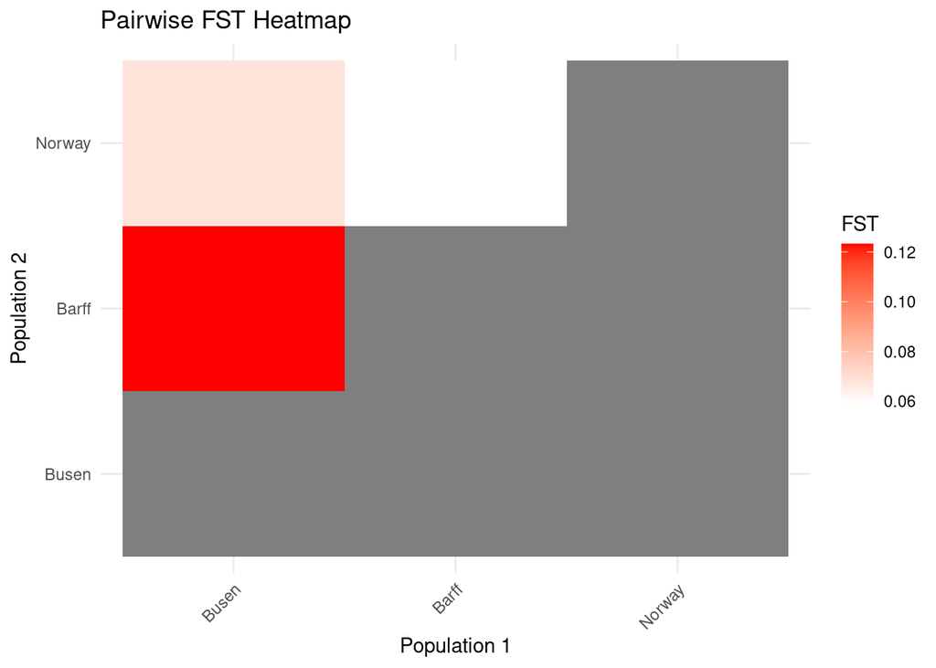

```r
ggplot(fst_df_exam, aes(x = Population2, y = Population1, fill = FST)) +
  geom_tile() +
  scale_fill_gradient(low = "white", high = "red", name = "FST") +
  theme_minimal() +
  theme(axis.text.x = element_text(angle = 45, hjust = 1)) +
  labs(title = "Pairwise FST Heatmap", x = "Population 1", y = "Population 2")
```

Here we can see the genetic differentiation corresponding to colors. White means there is a very low genetic differentiation, light red (pinkish) means there is a bit higher genetic differentiation and red or dark red means that there is a high genetic differentiations.

### Calculate and then produce a PCA plot. Explain what the plot represents (interpret the results of the analysis). What can you tell about the structure of your dataset?

```r
pca <- gl.pcoa(B)
```

```
## Starting gl.pcoa
##   Processing genlight object with SNP data
##   Performing a PCA, individuals as entities, loci as attributes, SNP genotype as state
```

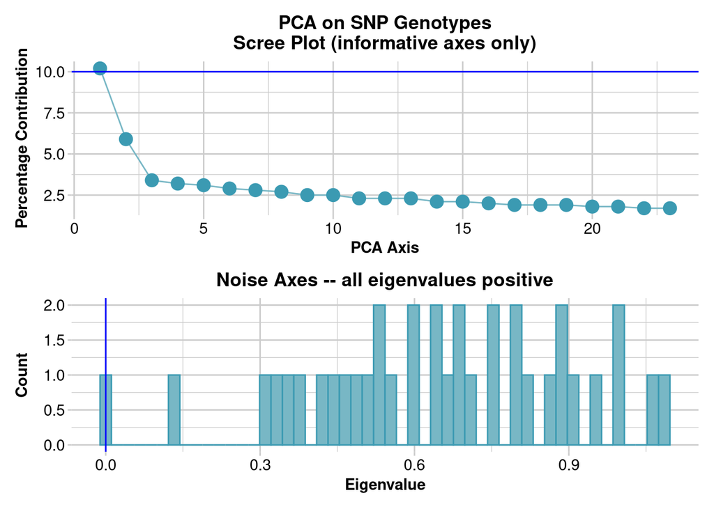

```
## Completed: gl.pcoa
```

```
## Starting gl.pcoa.plot
##   Processing an ordination file (glPca)
##   Processing genlight object with SNP data
##   Plotting populations in a space defined by the SNPs
##   Preparing plot .... please wait
```

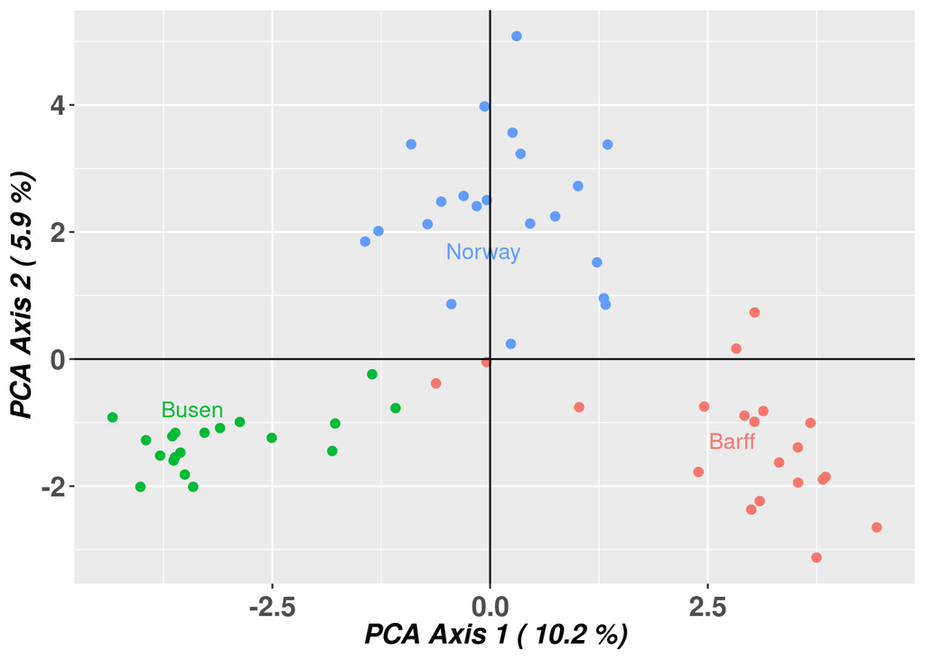

```
## Completed: gl.pcoa.plot
```

```r
gl.pcoa.plot(x = B, glPca = pca)
```

PCA (Principal component analysis) reduces the complexity of data sets while preserving the covariance (how two random variables are related) of the data. Scree plot (top) - The y-axis represents the percentage of variance that is explained by each principal component (PC). The x-axis represents the PCA components. - The blue horizontal line represents a threshold for selecting informative PCs. - The first few (two or three) PCs explain a significant proportion of variance (~10% for PC1, ~6% for PC2). After the first few PCs, the variance explained drops and stabilizes, indicating decrease of informative value. This suggests that only the first few PCs capture meaningful population structure, while later PCs may represent noise. Noise axes plot (bottom) - This histogram shows the distribution of eigenvalues corresponding to the less informative dimensions. - All eigenvalues are positive, meaning no negative variance components. - The distribution is more or less uniform, indicating that these axes mostly represent background noise rather than meaningful structure. - Since all eigenvalues are positive, the dataset has some structure rather than being completely random. The spread of eigenvalues suggests some weak signals beyond the first few PCs, but they are likely uninformative for distinguishing population groups.

There is genetic structure in the dataset, with a few principal components capturing most of the variation. A small number of PCs (e.g., PC1 and PC2) are sufficient to describe most of the meaningful differences between individuals/populations. The remaining PCs likely represent background noise rather than true genetic differentiation.

```
## Starting gl.pcoa.plot
##   Processing an ordination file (glPca)
##   Processing genlight object with SNP data
##   Plotting populations in a space defined by the SNPs
##   Preparing plot .... please wait
```

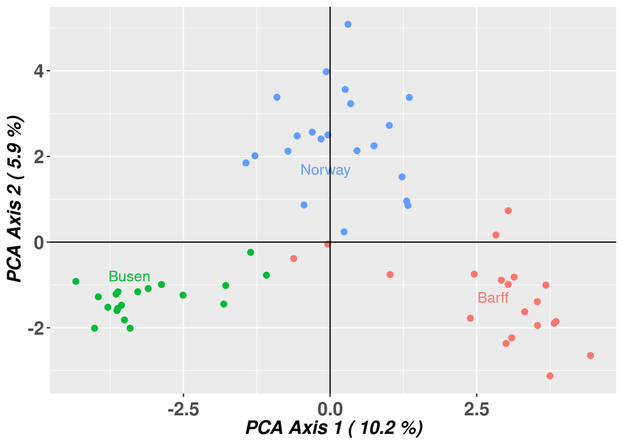

```
## Completed: gl.pcoa.plot
```

```r
gl.pcoa.plot(x = B, glPca = pca)
```

All three populations are well separated. Norway is well-separated along PCA Axis 2, showing distinct genetic variation, while Barff and Busen are mainly separated along PCA Axis 1, indicating stronger differentiation between them.

```r
gl.pcoa.plot(x = B, glPca = pca, zaxis = 3)
```

```
## Starting gl.pcoa.plot
##   Processing an ordination file (glPca)
##   Processing genlight object with SNP data
##   Displaying a three dimensional plot, mouse over for details for each point
##   May need to zoom out to place 3D plot within bounds
## Completed: gl.pcoa.plot
```

### How many populations are your study specimens included in the analysis divided into according to the molecular data? On the basis of which parameter can you make this conclusion? Use the arguments: k.range=1:10, num.k.rep=2, numreps=1000, burnin=1000, remember to specify other arguments. Graphically show the analysis of the structure of the populations. Interpret the results of the analysis of the structuring of the populations.

```r
str<-gl.run.structure(B[,1:1000], k.range= 1:10, num.k.rep = 2, exec= "./structure", numreps=1000, burnin=1000)
```

```
## Starting gl.run.structure
##   Processing genlight object with SNP data
```

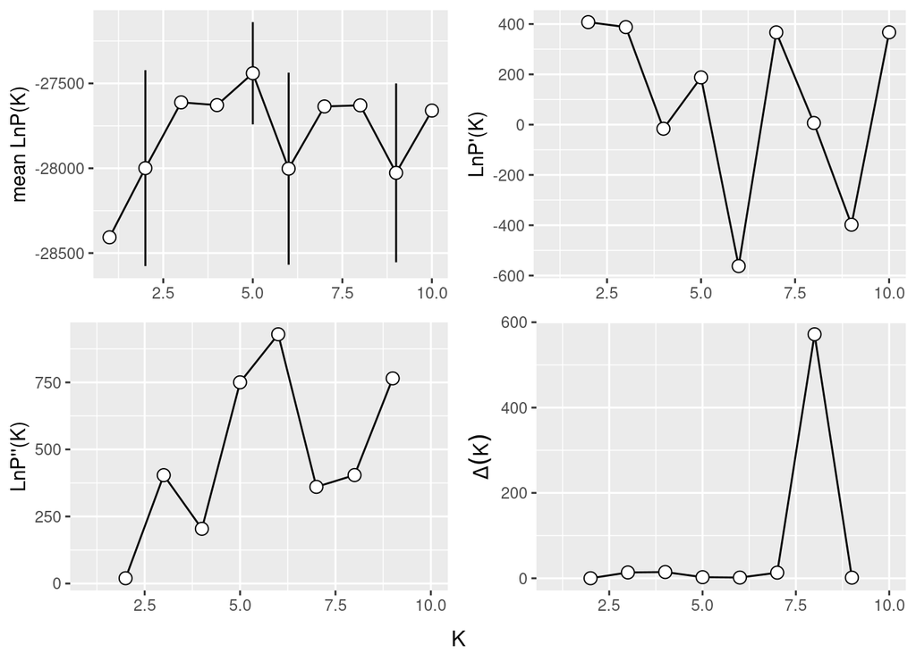

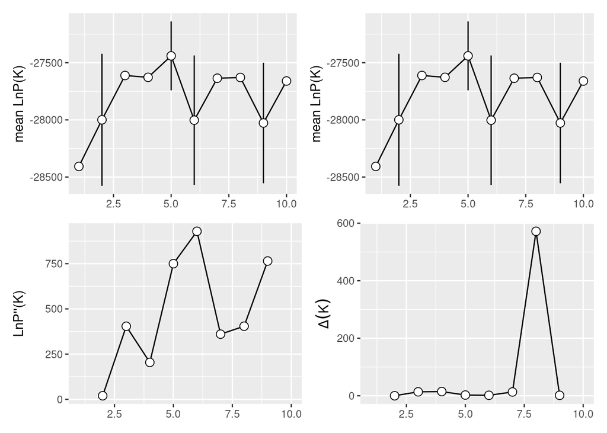

```
## Completed: gl.run.structure
```

```
## Starting gl.plot.structure
```

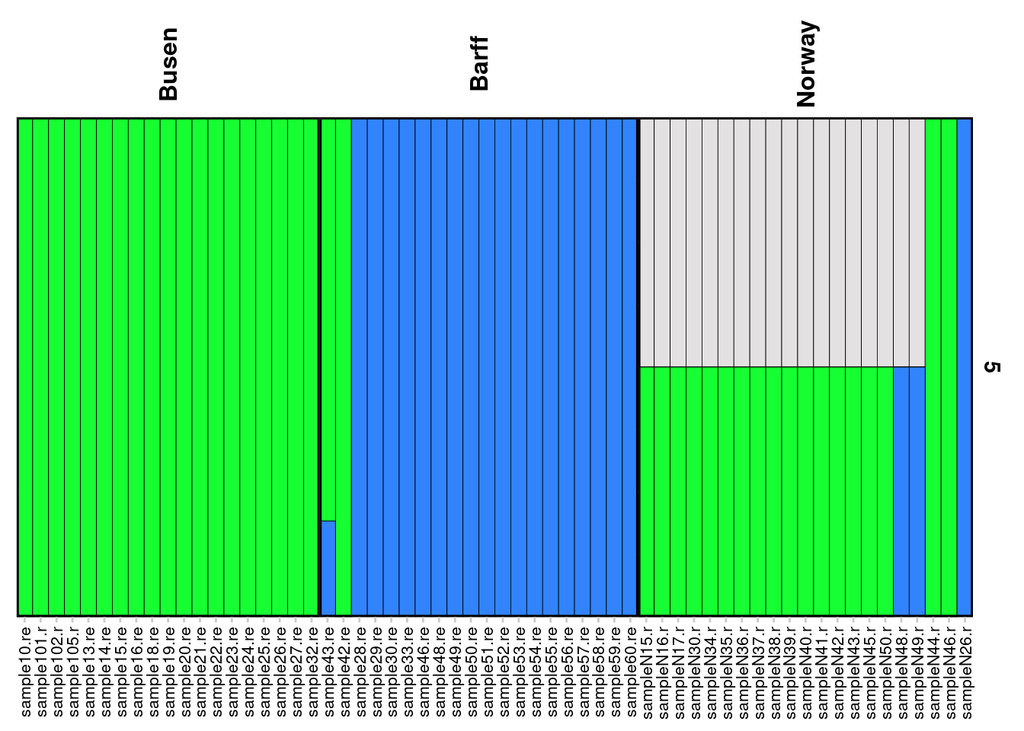

```
## Completed: gl.plot.structure
```

```r
gl.plot.structure(str,K = 5)
```